# Exercises 3

06/12/2018

## Example 1. Two component normal mixture model

We consider that $X$ is a random with *data generating process (DGP)* characterized by the *probability density function (PDF)*
$$f\left(x;\boldsymbol{\theta}\right)=\pi_{1}\phi\left(x;\mu_{1},\sigma_{1}^{2}\right)+\pi_{2}\phi\left(x;\mu_{2},\sigma_{2}^{2}\right),$$
where
$$\phi\left(x;\mu,\sigma^{2}\right)=\frac{1}{\sqrt{2\pi\sigma^{2}}}\exp\left(-\frac{1}{2}\frac{\left(x-\mu\right)^{2}}{\sigma^{2}}\right)$$
is a normal density function with mean $\mu$ and variance $\sigma^2$, and $\pi_1>0$, $\pi_2>0$, and
$$\pi_{1}+\pi_{2}=1.$$
Here, we put all of the parameters into the vector $\boldsymbol{\theta}^{\top}=\left(\pi_{1},\pi_{2},\mu_{1},\mu_{2},\sigma_{1}^{2},\sigma_{2}^{2}\right)$.

We suppose that we observe $n=100$ *independent and identically distributed (IID)* samples $X_1,\dots,X_n$, from the scenario where
$$\boldsymbol{\theta}^{\top}=\left(0.5,0.5,-2,2,1,1\right).$$
We shall firstly visualize this scenario via a histogram.

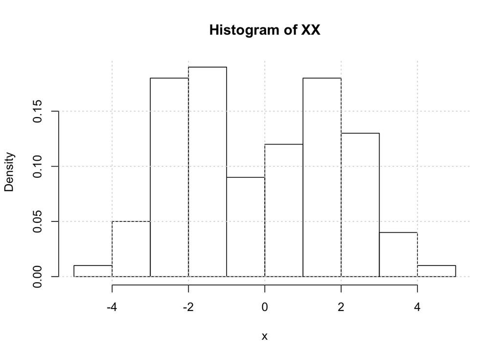

```r
# Set a random seed
set.seed(123)
# Set pi
Pi <- c(0.5,0.5)
# Set mu
Mu <- c(-2,2)
# Set sigma^2
Sigma_s <- c(1,1)
# Set n
nn <- 100
# Define a function for sampling from a discrete distribution with the parameters Pi
sampler <- function(n) {
  # Get cutoff values
  cutoff <- cumsum(Pi)
  # Generate n uniform random variables
  rando <- runif(n)
  # Obtain the random sample using the cutoffs
  samp <- sapply(rando,
                 function(rr) {which(cutoff>rr)[1]})
}
# Obtain a sample from the discrete distribution
ZZ <- sampler(nn)
# Initialize a vector to store the X values
XX <- c()
# Using the discrete sample, generate a sample from the desired mixture model
for (zz in 1:2) {
  XX <- c(XX,
              rnorm(sum(ZZ==zz),Mu[zz],sqrt(Sigma_s[zz])))
}
# Plot a histogram
hist(XX,xlab='x',probability = T)
# Add a grid
grid()
```

We will use the `mixtools` package of in order to fit a normal mixture model to the data. If you have not already installed the package, run the command `install.packages('mixtools')`. Although `mixtools` is somewhat slower and older than other packages, we prefer it due to its simplicity of use and clear reporting style.

```r
# Load the mixtools package
library(mixtools)
# Set your initial values theta_(0) at the true generative values
Pi0 <- Pi
Mu0 <- Mu
Sigma_s0 <- Sigma_s
# Use the normalmixEM function form mixtools to fit a mixture model (k is the number of components here)
mixfit <- normalmixEM(XX,
                      Pi0, Mu0, sqrt(Sigma_s0),
                      k=2)
```

```
## number of iterations= 27
```

```r
# Display the parameter estimates, noting that normalmixEM uses the notation lambda for pi
summary(mixfit)
```

```
## summary of normalmixEM object:
##           comp 1   comp 2
## lambda  0.485348 0.514652
## mu     -2.002221 1.550621
## sigma   0.791839 1.159742
## loglik at estimate:  -198.7077
```

We can also access the estimated parameters and utilize them to plot a graph over our histogram data.

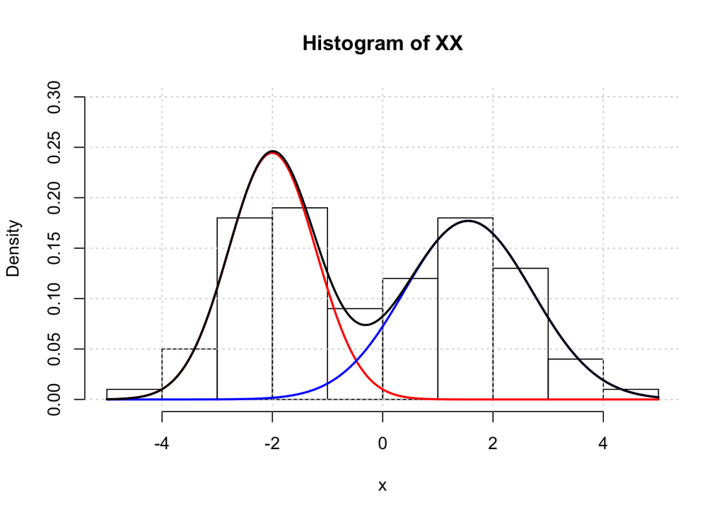

```r
# Access fitted values
Pi_hat <- mixfit$lambda
Mu_hat <- mixfit$mu
Sigma_s_hat <- mixfit$sigma^2
# Plot the histogram again
hist(XX,xlab='x',probability = T,ylim=c(0,0.3))
# Add a grid
grid()
# Make a dummy variable for the plot device
dum <- seq(-5,5,length.out = 1000)
# Plot the component densities in red and blue
lines(dum,
      Pi_hat[1]*dnorm(dum,Mu_hat[1],sqrt(Sigma_s_hat[1])),
      col='red',lwd=2)
lines(dum,
      Pi_hat[2]*dnorm(dum,Mu_hat[2],sqrt(Sigma_s_hat[2])),
      col='blue',lwd=2)
# Plot the overvall mixture model in black
lines(dum,
      Pi_hat[1]*dnorm(dum,Mu_hat[1],sqrt(Sigma_s_hat[1]))+
      Pi_hat[2]*dnorm(dum,Mu_hat[2],sqrt(Sigma_s_hat[2])),
      lwd=2)
```

## Exercise 1. A three component mixture

Consider instead IID data $X_1,\dots,X_n$, $n=100$ using `set.seed(321)`, from the normal mixture model
$$f\left(x;\boldsymbol{\theta}\right)=\pi_{1}\phi\left(x;\mu_{1},\sigma_{1}^{2}\right)+\pi_{2}\phi\left(x;\mu_{2},\sigma_{2}^{2}\right)+\pi_{3}\phi\left(x;\mu_{3},\sigma_{3}^{2}\right),$$
where
$$\boldsymbol{\theta}^{\top}=\left(\pi_{1},\pi_{2},\pi_{3},\mu_{1},\mu_{2},\mu_{3},\sigma_{1}^{2},\sigma_{2}^{2},\sigma_{3}^{2}\right)=\left(0.5,0.3,0.2,0,2,4,1,2,3\right).$$
We can visualize this sample via a histogram:

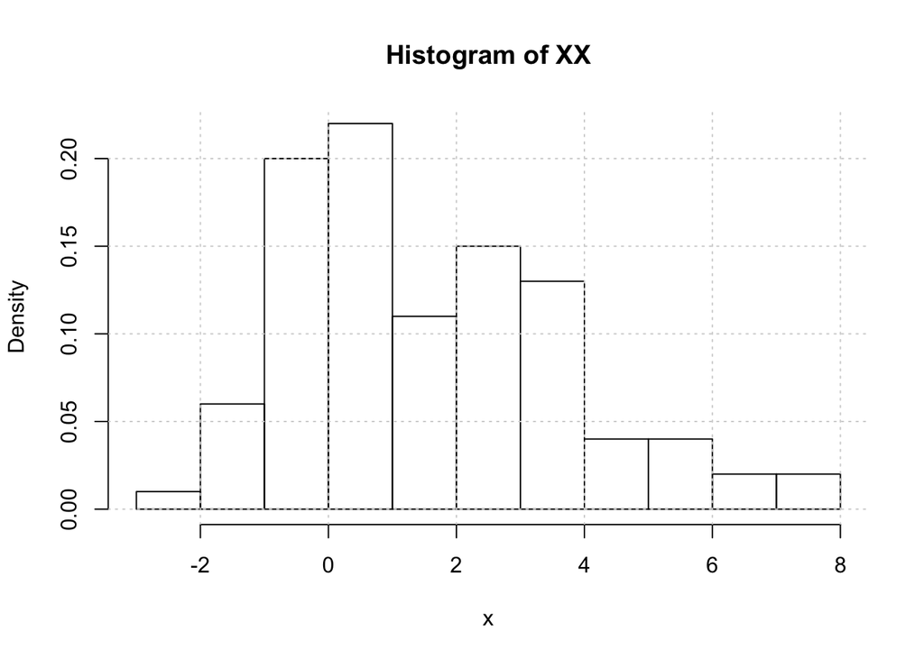

```r
# Set a random seed
set.seed(321)
# Set pi
Pi <- c(0.5,0.3,0.2)
# Set mu
Mu <- c(0,2,4)
# Set sigma^2
Sigma_s <- c(1,2,3)
# Set n
nn <- 100
# Define a function for sampling from a discrete distribution with the parameters Pi
sampler <- function(n) {
  # Get cutoff values
  cutoff <- cumsum(Pi)
  # Generate n uniform random variables
  rando <- runif(n)
  # Obtain the random sample using the cutoffs
  samp <- sapply(rando,
                 function(rr) {which(cutoff>rr)[1]})
}
# Obtain a sample from the discrete distribution
ZZ <- sampler(nn)
# Initialize a vector to store the X values
XX <- c()
# Using the discrete sample, generate a sample from the desired mixture model
for (zz in 1:3) {
  XX <- c(XX,
              rnorm(sum(ZZ==zz),Mu[zz],sqrt(Sigma_s[zz])))
}
# Plot a histogram
hist(XX,xlab='x',probability = T)
# Add a grid
grid()
```

Modify the script from **Example 1** in order to fit the data using a 3-component normal mixture model, using the generative parameter vector
$$\boldsymbol{\theta}^{\top}=\left(\pi_{1},\pi_{2},\pi_{3},\mu_{1},\mu_{2},\mu_{3},\sigma_{1}^{2},\sigma_{2}^{2},\sigma_{3}^{2}\right)$$
as the initialization $\boldsymbol{\theta}^{(0)}$.

> Use alternative initialization values in your code, and observe what you obtain. When you specify no initial values, the function will randomize the inialization for you. What can be said about the initialization’s influence on the obtained solution? Do you think that the maximum likelihood problem for the mixture model has a unique global optimum?

## Exercise 2. Kernel density estimation

Suppose that we observe a sample $X_1,\dots,X_n$ from a DGP with unknown density function $f$. One method to estimate this density function is via a *kernel density estimator*
$$\widehat{f}\left(x\right)=\frac{1}{nh}\sum_{i=1}^{n}K\left(\frac{x-X_{i}}{h}\right),$$
where $h>0$ is the *bandwidth* and $K(x)$ is a so-called *kernel* function, which can be taken as a PDF for a random variable with mean *zero*.

Consider the following data:

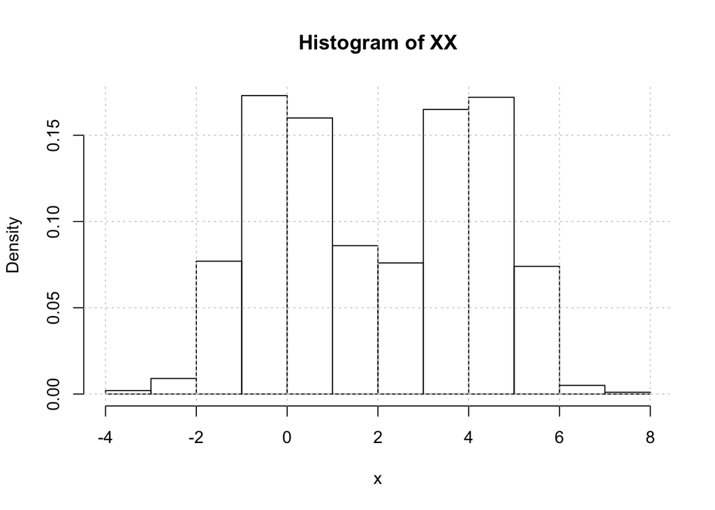

```r
# Set random seed
set.seed(123)
# Set n
nn <- 1000
# Generate random data
XX <- c(rt(nn/2,df=100), 4 + rt(nn/2,df=30))
# Visualize the data via a histogram
hist(XX,xlab='x',probability = T)
# Add a grid
grid()
```

Using the `density` function, we can construct kernel density estimator for the data.

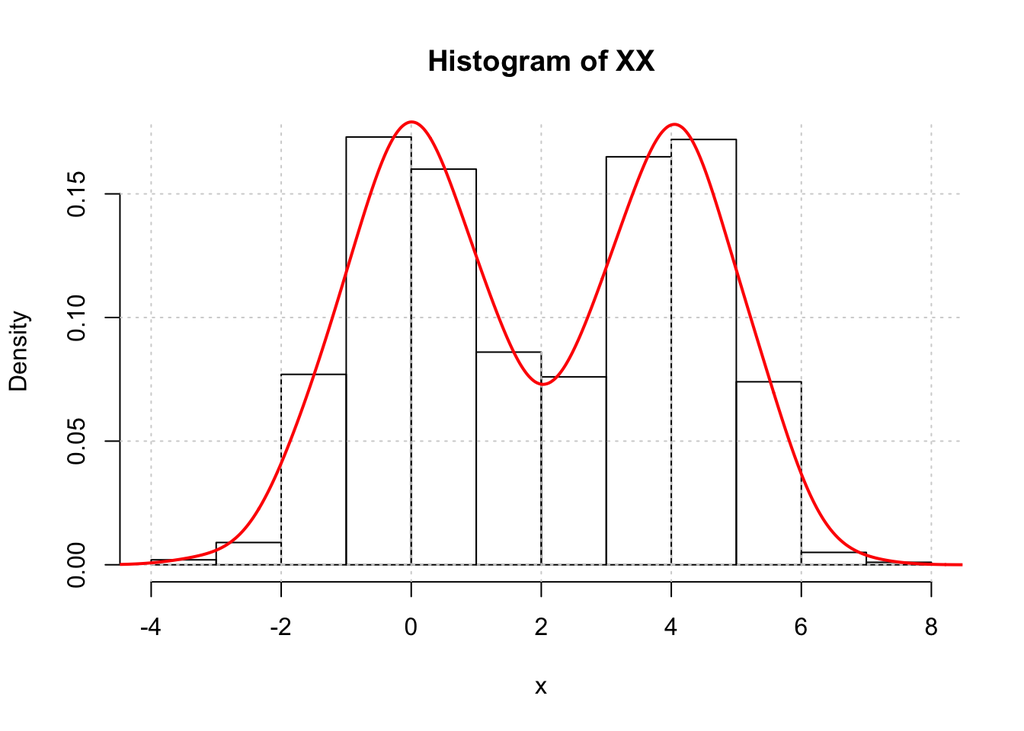

```r
# Construct a kernel density estimator
kde <- density(XX)
# Visualize the data via a histogram
hist(XX,xlab='x',probability = T)
# Add a grid
grid()
# Plot the kernel density estimator on top
lines(kde,lwd=2,col='red')
```

We notice that the kernel density estimator provides a good fit to the data.

> The default settings for `density` utilizes the kernel $K\left(x\right)=\phi\left(x;0,1\right)$. With this in mind, what can be said regarding the relationship between kernel density estimators and normal mixture models. The `density` function allows for modification of the kernel. Try different kernels and observe any differences in the outcome.

> The kernel density estimator is often used as an all-purpose density estimation tool. When can it fail?

## Example 2. Multivariate mixture model

We consider the classic **iris** data, which can be loaded by the script `data(iris)`. The data contains $n=150$ observations of $d=4$ different measurements of the iris flower arising from $g=3$ species of irises.

The measurements are sepal length, sepal width, petal length, and petal width. The species are *setosa*, *versicolor*, and *virginica*.

We can compute the summary statistics of the measurements of each species as follows.

```r
# Load the iris data
data(iris)
# Obtain the setosa summary
summary(iris[which(iris$Species=='setosa'),1:4])
```

```
##   Sepal.Length    Sepal.Width     Petal.Length    Petal.Width
##  Min.   :4.300   Min.   :2.300   Min.   :1.000   Min.   :0.100
##  1st Qu.:4.800   1st Qu.:3.200   1st Qu.:1.400   1st Qu.:0.200
##  Median :5.000   Median :3.400   Median :1.500   Median :0.200
##  Mean   :5.006   Mean   :3.428   Mean   :1.462   Mean   :0.246
##  3rd Qu.:5.200   3rd Qu.:3.675   3rd Qu.:1.575   3rd Qu.:0.300
##  Max.   :5.800   Max.   :4.400   Max.   :1.900   Max.   :0.600
```

```r
# Obtain the versicolor summary
summary(iris[which(iris$Species=='versicolor'),1:4])
```

```
##   Sepal.Length    Sepal.Width     Petal.Length   Petal.Width
##  Min.   :4.900   Min.   :2.000   Min.   :3.00   Min.   :1.000
##  1st Qu.:5.600   1st Qu.:2.525   1st Qu.:4.00   1st Qu.:1.200
##  Median :5.900   Median :2.800   Median :4.35   Median :1.300
##  Mean   :5.936   Mean   :2.770   Mean   :4.26   Mean   :1.326
##  3rd Qu.:6.300   3rd Qu.:3.000   3rd Qu.:4.60   3rd Qu.:1.500
##  Max.   :7.000   Max.   :3.400   Max.   :5.10   Max.   :1.800
```

```r
# Obtain the virginica summary
summary(iris[which(iris$Species=='virginica'),1:4])
```

```
##   Sepal.Length    Sepal.Width     Petal.Length    Petal.Width
##  Min.   :4.900   Min.   :2.200   Min.   :4.500   Min.   :1.400
##  1st Qu.:6.225   1st Qu.:2.800   1st Qu.:5.100   1st Qu.:1.800
##  Median :6.500   Median :3.000   Median :5.550   Median :2.000
##  Mean   :6.588   Mean   :2.974   Mean   :5.552   Mean   :2.026
##  3rd Qu.:6.900   3rd Qu.:3.175   3rd Qu.:5.875   3rd Qu.:2.300
##  Max.   :7.900   Max.   :3.800   Max.   :6.900   Max.   :2.500
```

We observe that the three flower species have quite different distribution in measurements. This can further be visualized if we plot the data in a *matrix plot*.

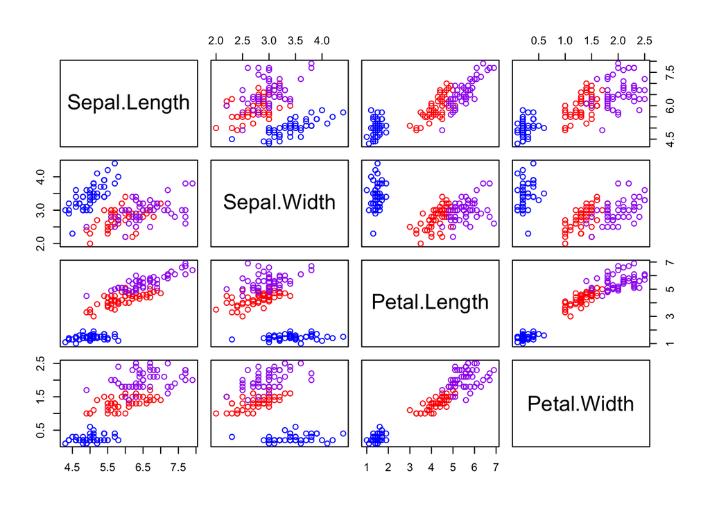

```r
# Plot the data in a matrix plot
plot(iris[,1:4],
     col=c('blue','red','purple')[as.numeric(iris[,5])])
```

Clearly the data arises from three different populations, as we know from the data generating process that has been observed thus far.

Suppose however, that we do not know the species of each observation, but only observe the $d=4$ measurements. Then, we would only be observing the following picture.

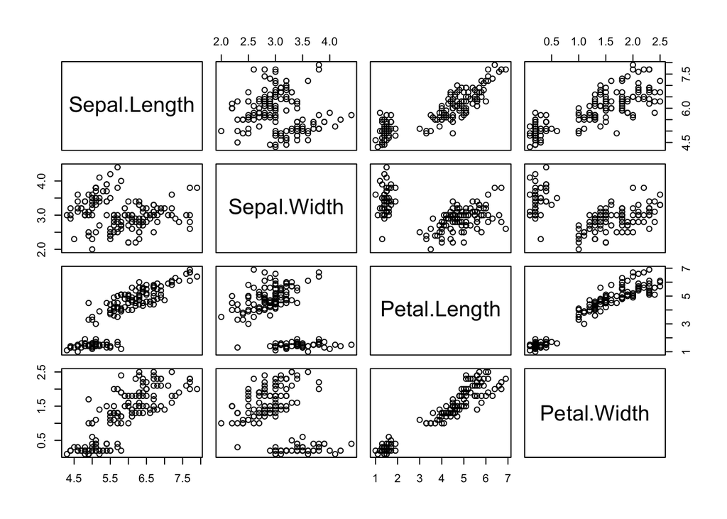

```r
# Plot the data in a matrix plot
plot(iris[,1:4])
```

Due to its hierachical form, we know that it may be possible to retrieve the $g=3$ population structure from the data. We can do this by using *maximum likelihood estimation* to fit the mixture model
$$f\left(x;\boldsymbol{\theta}\right)=\pi_{1}\phi\left(x;\boldsymbol{\mu}_{1},\boldsymbol{\Sigma}_{1}\right)+\pi_{2}\phi\left(x;\boldsymbol{\mu}_{2},\boldsymbol{\Sigma}_{2}\right)+\pi_{3}\phi\left(x;\boldsymbol{\mu}_{3},\boldsymbol{\Sigma}_{3}\right),$$
where
$$\phi\left(\boldsymbol{x};\boldsymbol{\mu},\boldsymbol{\Sigma}\right)=\left|2\pi\boldsymbol{\Sigma}\right|^{-1/2}\exp\left[-\frac{1}{2}\left(\boldsymbol{x}-\boldsymbol{\mu}\right)^{\top}\boldsymbol{\Sigma}^{-1}\left(\boldsymbol{x}-\boldsymbol{\mu}\right)\right]$$
is the multivariate normal PDF with mean vector $\boldsymbol{\mu}$ and covariance matrix $\boldsymbol{\Sigma}$. Here $\pi_1+\pi_2+\pi_3=1$ and we put all of the elements of $\pi_z$, $\boldsymbol{\mu}_z$, and $\boldsymbol{\Sigma}_z$ ($z=1,2,3$) into $\boldsymbol{\theta}$.

The three component mixture model above can be fitted using the `mvnormalmixEM` function from `mixtools` as follows.

```r
# Load the mixtools package
library(mixtools)
# Set random seed
set.seed(111)
# Fit the mixture model using mixtools (recall that k is the number of components)
mixfit <- mvnormalmixEM(iris[,-5],
                        k=3)
```

```
## number of iterations= 200
```

```r
# Obtain the estimated mixing proportions
mixfit$lambda
```

```
## [1] 0.3332880 0.2293453 0.4373667
```

```r
# Obtain the estimated means
mixfit$mu
```

```
## [[1]]
## [1] 5.0060685 3.4281527 1.4620219 0.2459925
##
## [[2]]
## [1] 6.383977 2.992939 5.343599 2.108472
##
## [[3]]
## [1] 6.197856 2.808523 4.676159 1.449079
```

```r
# Obtain the estimated covariances
mixfit$sigma
```

```
## [[1]]
##            [,1]        [,2]        [,3]        [,4]
## [1,] 0.12174586 0.097167922 0.016019072 0.010129071
## [2,] 0.09716792 0.140662845 0.011440814 0.009121481
## [3,] 0.01601907 0.011440814 0.029556448 0.005949967
## [4,] 0.01012907 0.009121481 0.005949967 0.010885032
##
## [[2]]
##            [,1]       [,2]       [,3]       [,4]
## [1,] 0.27404566 0.07716854 0.16163458 0.06973453
## [2,] 0.07716854 0.07340221 0.06664668 0.04269455
## [3,] 0.16163458 0.06664668 0.16793756 0.07376820
## [4,] 0.06973453 0.04269455 0.07376820 0.05847177
##
## [[3]]
##           [,1]       [,2]      [,3]       [,4]
## [1,] 0.5076934 0.13217070 0.5573041 0.17371525
## [2,] 0.1321707 0.11692922 0.1384065 0.05662739
## [3,] 0.5573041 0.13840648 0.7885673 0.24614171
## [4,] 0.1737152 0.05662739 0.2461417 0.09223767
```

> Comparing the estimated mean values, does it appear as if the three different subspecies of irises have been identified? What about the estimated mixing proportions?

Using the notion of *maximum a posteriori* clustering, we can seperate the $n$ observations into *clusters*, based on which of the $g=3$ fitted normal mixture components they are closest to. That is, for which $z=1,2,3$ is the value
$$\pi_{z}\phi\left(\boldsymbol{x};\boldsymbol{\mu}_{z},\boldsymbol{\Sigma}_{z}\right),$$
the largest, when we substitute the maximum likelihood estimate in for the parameter vector.

We can perform the *clustering* as follows.

```r
# Perform the clustering
clustering <- apply(mixfit$posterior,1,which.max)
# Print the first 6 outputs
head(clustering)
```

```
## [1] 1 1 1 1 1 1
```

> We see that the first six outputs are all in the same cluster. Is this a promising result?

We now plot the clustering of each observation together in a different shape, along with the true species of each observation, in a different color.

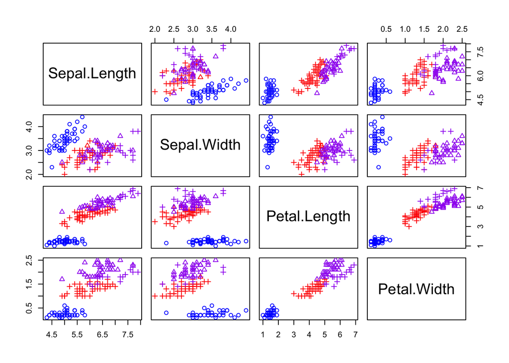

```r
# Plot the data in a matrix plot
plot(iris[,1:4],
     col=c('blue','red','purple')[as.numeric(iris[,5])],
     pch=clustering)
```

> How successful have we been in capturing the subpopulations from this data? Given that the algorithm is initialized different each time it is run, can we conclude that there is a unique global optimal solution to the maximum likelihood estimat problem here?

## Example 3. Repeated measurements

Suppose that we observe $m=10$ measurements, at time points $k=1,\dots,m$, each from $n=10$ different individuals indexed by $i=1,\dots,n$. Thus for each individual we observe $m$ measurements
$$\boldsymbol{Y}_{i}^{\top}=\left(Y_{i1},\dots,Y_{im}\right),$$
at $m$ covariate vectors
$$\boldsymbol{x}_{1}^\top=\left(1,1\right),\dots\boldsymbol{x}_{m}^\top=\left(1,m\right).$$
Suppose that there is a fixed effect $\boldsymbol{\beta}^\top=(1,1)$ that determines the overall effect of all of the individuals to the covariate vectors $\boldsymbol{x}_k=(1,k)$ ($k=1,\dots,m$).

From the setup so far, we know that observation $Y_{ik}$ from individual $i$ is generated via the linear model
$$Y_{ik}=\left(\boldsymbol{\beta}+\boldsymbol{B}_{i}\right)^{\top}\boldsymbol{x}_{ik}+E_{ik}.$$
With the notation that $\mathbf{X}_{i}$ contains the rows $\boldsymbol{x}_{ik}^\top$ and
$$\boldsymbol{E}_{i}^{\top}=\left(E_{i1},\dots,E_{im}\right),$$
we can write the model as
$$\boldsymbol{Y}_{i}=\mathbf{X}_{i}\left(\boldsymbol{\beta}+\boldsymbol{B}_{i}\right)+\boldsymbol{E}_{i}.$$

We plot the data $(Y_ik,k)$ for each individual $i=1,\dots,n$ along with the overal mean relationship
$$y=\beta_{1}+\beta_{2}k,$$
and each of the individual relationships, specific to individual $i$,
$$y_{i}=\beta_{1}+B_{i1}+\left(\beta_{2}+B_{i2}\right)k.$$

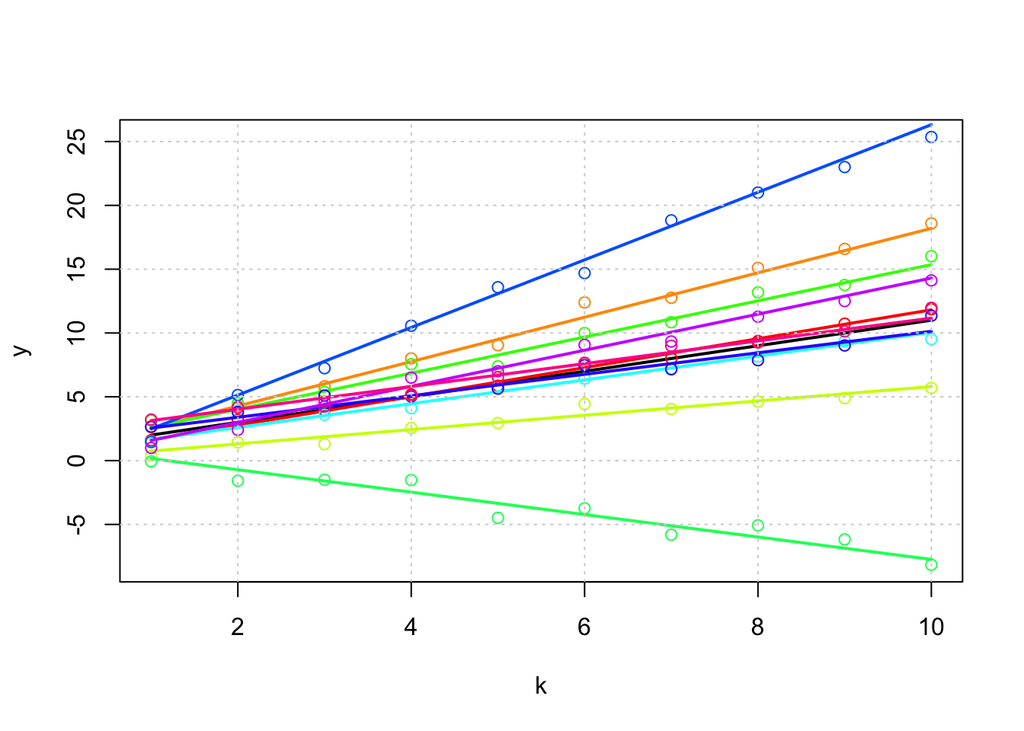

```r
# Set random seed
set.seed(100)
# Set n
nn <- 10
# Set m
mm <- 10
# Create a list to store Y_i vectors
ylist <- list()
# Create a list to store B_i vectors
Blist <- list()
# Create a list to store X_i matrices
Xlist <- list()
# Use a loop to generate the data
for (ii in 1:nn) {
  # Make the X matrices
  Xlist[[ii]] <- cbind(1,1:mm)
  # Make the B vectors
  Blist[[ii]] <- rnorm(2,0,1)
  # Generate the Y values
  ylist[[ii]] <- Xlist[[ii]]%*%(matrix(Blist[[ii]],2,1)+matrix(c(1,1),2,1))+rnorm(mm,0,0.5)
}
# Plot the mean function
plot(1:nn,1+1:nn,type='l',lwd=2,xlab='k',ylab='y',ylim=c(min(unlist(ylist)),max(unlist(ylist))))
for (ii in 1:nn) {
  # Plot each set of points
  points(1:nn,ylist[[ii]],col=rainbow(nn)[ii])
  # Plot each mean line
  lines(1:nn,1+Blist[[ii]][1]+(1+Blist[[ii]][2])*(1:nn),
        col=rainbow(nn)[ii],lwd=2,lty=1)
}
# Draw a grid
grid()
```

We can use the `lmer` function from the `lme4` library in order to estimate the parameters $\boldsymbol{\beta}$, $\mathbf{V}$, and $\sigma^{2}$, of a repeated measures model. We can install `lme4` via the command `install.packages('lme4')`.

In order to fit our model, we must first reformat our data into a form compatible with `lmer`. We can then fit the model as follows.

```r
# Load lme4 package
library(lme4)
```

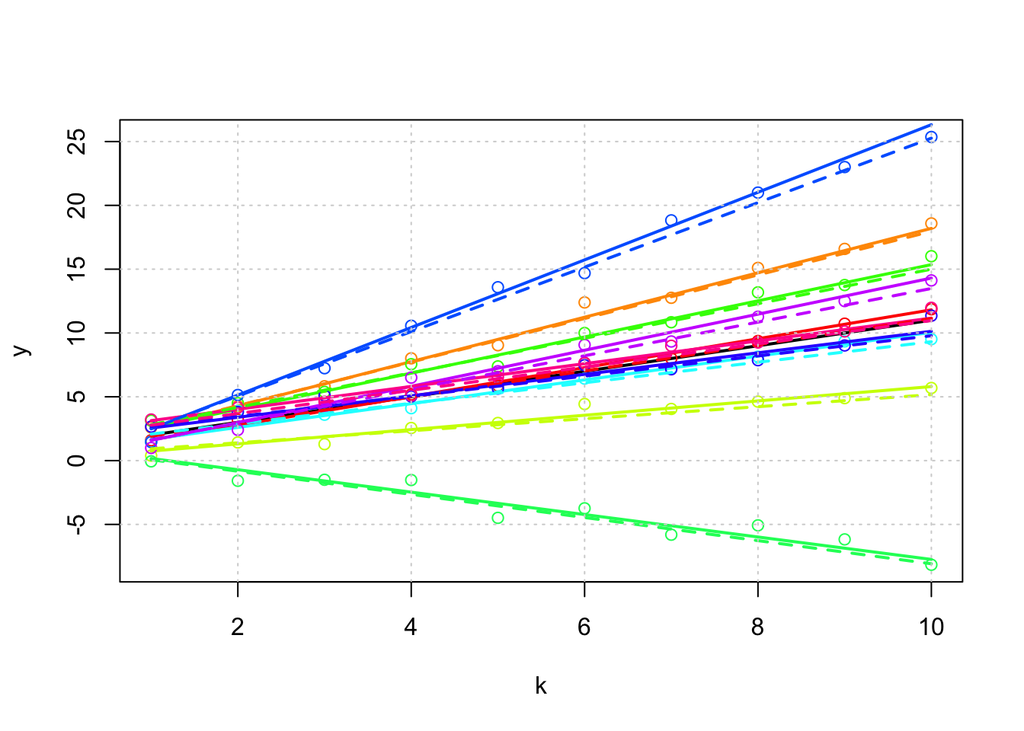

```r
# Put data in long format with three columns for y, k, and i
data_forlmm <- as.data.frame(cbind(unlist(ylist),
                                   rep(1:10,10),
                                   unlist(lapply(1:10,rep,10))))
# Name the columns
names(data_forlmm) <- c('y','k','i')
# Fit the repeated measures model (REML=F turns on MLE)
lmm <- lmer(y~k+(1+k|i),data=data_forlmm,REML=F)
# Extract the coefficients B_i from the fitted model
coeffs <- ranef(lmm)$i
# Plot the mean function
plot(1:nn,1+1:nn,type='l',lwd=2,xlab='k',ylab='y',ylim=c(min(unlist(ylist)),max(unlist(ylist))))
for (ii in 1:nn) {
  # Plot each set of points
  points(1:nn,ylist[[ii]],col=rainbow(nn)[ii])
  # Plot each mean line
  lines(1:nn,1+Blist[[ii]][1]+(1+Blist[[ii]][2])*(1:nn),
        col=rainbow(nn)[ii],lwd=2,lty=1)
}
# Begin a loop to plot the individual lines
for (ii in 1:nn) {
  # Plot the individual lines in dashed lines
  lines(1:nn,1+coeffs[ii,1]+(1+coeffs[ii,2])*(1:nn),
        col=rainbow(nn)[ii],lwd=2,lty=2)
}
# Add a grid
grid()
```